# **Global Shipments Data**

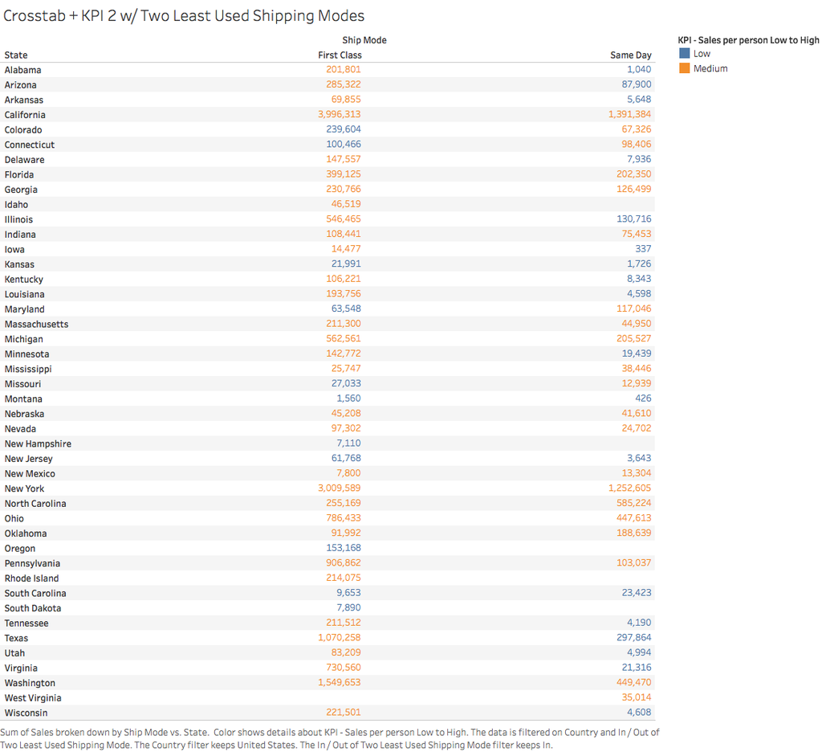

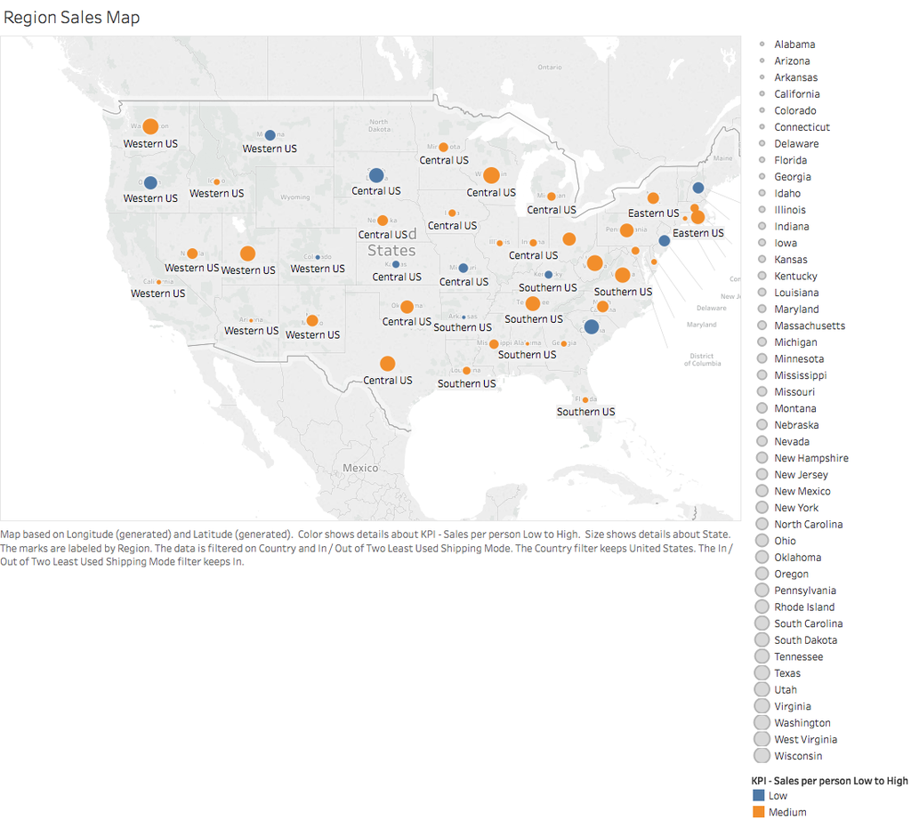

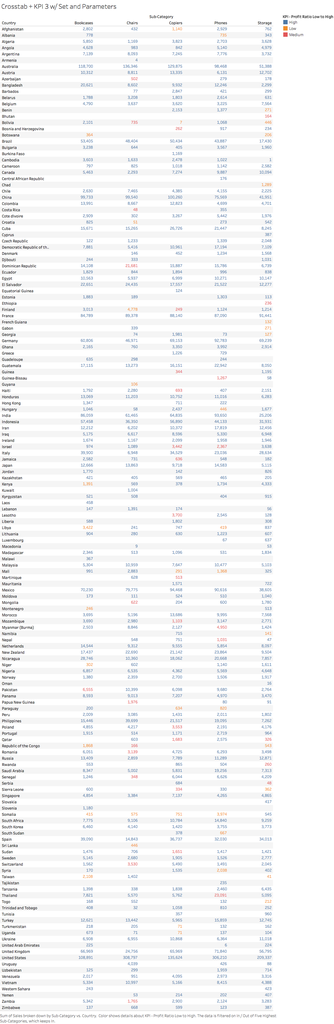

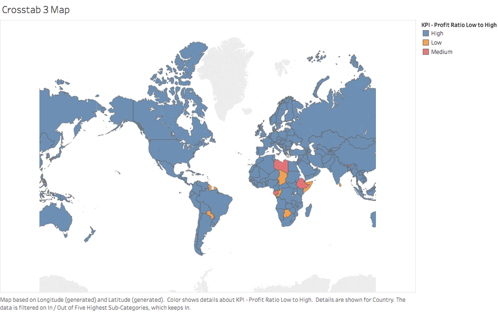

# **Shiny Visualization and Published Application**

**Description:** A static .png of the Shiny application, as well as a link to the live published version. Crosstab 1 sums up the shipping costs by segment and state. The data is filtered on Country = United States and dislays the IN of Two Highest Shipping Segments.  
Crosstab 2 breaks down the sum of sales by ship mode and state. The color highlights KPI - Sales per person Low to High. Again, the data is filtered on Country = United States and IN for Two Least Used Shipping Mode.  
Lastly, Crosstab 3 covers sum of sales by sub-category and country. KPI reflects the profit to sales ratio low to high. The data is filtered on IN for Five Highest Sub-Categories.

Published Link:  
https://frannyfang.shinyapps.io/crosstab1/  
https://frannyfang.shinyapps.io/crosstab2/  
https://frannyfang.shinyapps.io/Crosstab3/

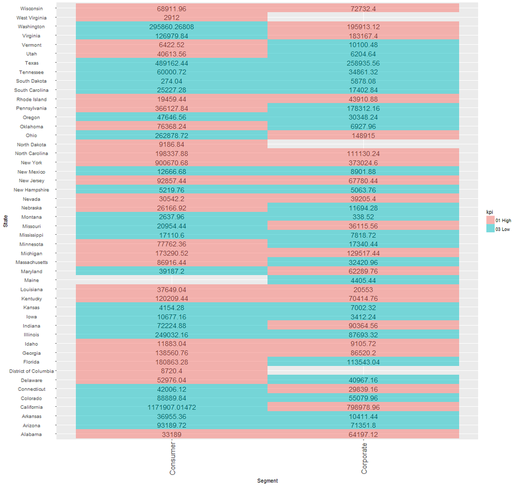

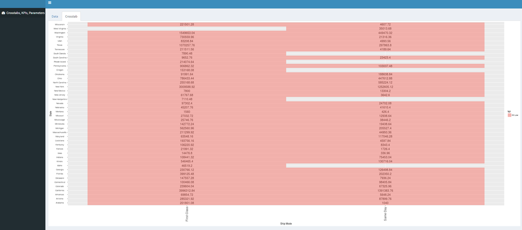

[figure not shown]